# Prediction of the clients age for the grocery store

# Content

1. Project Description
2. Data import and Analysis
3. Code
4. GPU prediction results
5. General Conclusion

# Project Description

Grocery store wants to use computer vision system for the clients photos processing for definition of their ages. It would help the store to analyze the purchases and suggest the relevant products for the exact clients age group, in addition it would check the cashier behavior during the sell of the age restricted products in accordance with compliance with law. For the realization of such tool it's required to train a model which predicts the approximate age of the client by the photo.

**Main task - using computer vision tools an machine learning to predict the buyer's age in the shop.**

The following tasks to be performed:

- data import and exploratory analysis;
- prepare the code and upload it on GPU
- upload the code on GPU for prediction calculation;
- to analyze the the results of prediction;
- draw a conclusion

# Data import and expolatory analysis

**Import of libraries and data load**

```python
from tensorflow.keras.datasets import fashion_mnist
from tensorflow.keras.layers import Dense
from tensorflow.keras.models import Sequential
from tensorflow.keras.layers import Conv2D, Flatten, Dense, MaxPooling2D
from tensorflow.keras.optimizers import Adam
from tensorflow.keras.preprocessing.image import ImageDataGenerator
import numpy as np
import pandas as pd
import matplotlib.pyplot as plt
```

```python
datagen = ImageDataGenerator(validation_split = 0.25,
                            rescale = 1/255)
```

```python
train_datagen_flow = datagen.flow_from_directory('/datasets/faces/',
                                                 target_size = (150,150),
                                                 batch_size = 16,
                                                 class_mode = 'sparse',
                                                 seed = 12345)
```

```
Found 7591 images belonging to 1 classes.
```

```python
features, target = next(train_datagen_flow)
```

```python
target
```

```
array([0., 0., 0., 0., 0., 0., 0., 0., 0., 0., 0., 0., 0., 0., 0., 0.],
      dtype=float32)
```

```python
df_age = pd.read_csv('/datasets/faces/labels.csv')
```

**Display the information on the quantity of records in dataset, analyze the statistic of data and display a few pictures of buyers**

```python
df_age.info()
```

```
<class 'pandas.core.frame.DataFrame'>
RangeIndex: 7591 entries, 0 to 7590
Data columns (total 2 columns):
 #   Column     Non-Null Count  Dtype
---  ------     --------------  -----
 0   file_name  7591 non-null   object
 1   real_age   7591 non-null   int64
dtypes: int64(1), object(1)
memory usage: 118.7+ KB
```

```
<BarContainer object of 97 artists>
```

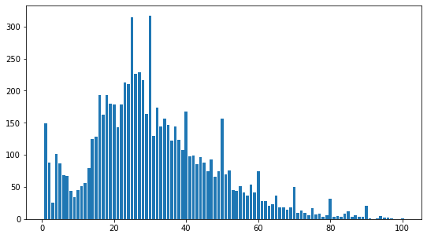

```python
df_count_by_age = df_age.groupby('real_age').count().sort_values(by = 'file_name', ascending = False).reset_index()
df_count_by_age = df_count_by_age.rename(columns={"file_name": "count"})
plt.figure(figsize=(9, 5))
plt.bar(df_count_by_age['real_age'],df_count_by_age['count'])
```

```python
df_count_by_age[df_count_by_age['real_age'] == df_count_by_age['real_age'].min()]
```

|  | real_age | count |
| --- | --- | --- |
| 18 | 1 | 149 |

```python
df_count_by_age[df_count_by_age['real_age'] == df_count_by_age['real_age'].max()]
```

|  | real_age | count |
| --- | --- | --- |
| 96 | 100 | 1 |

```
<BarContainer object of 20 artists>
```

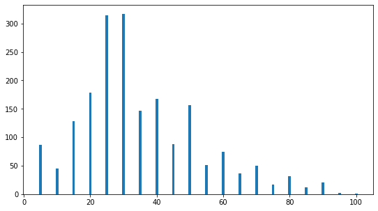

```python
df_count_by_age_five = df_count_by_age[df_count_by_age['real_age'] % 5 == 0].reset_index(drop =True)
plt.figure(figsize=(9, 5))
plt.bar(df_count_by_age_five['real_age'],df_count_by_age_five['count'])
```

```python
df_count_by_age_five.sort_values(by = 'real_age').reset_index(drop =True)
```

|  | real_age | count |
| --- | --- | --- |
| 0 | 5 | 87 |
| 1 | 10 | 45 |
| 2 | 15 | 128 |
| 3 | 20 | 178 |
| 4 | 25 | 315 |
| 5 | 30 | 317 |
| 6 | 35 | 147 |
| 7 | 40 | 167 |
| 8 | 45 | 88 |
| 9 | 50 | 156 |
| 10 | 55 | 51 |
| 11 | 60 | 75 |
| 12 | 65 | 36 |
| 13 | 70 | 50 |
| 14 | 75 | 17 |
| 15 | 80 | 31 |
| 16 | 85 | 12 |
| 17 | 90 | 21 |
| 18 | 95 | 2 |
| 19 | 100 | 1 |

[figure not shown]

```python
fig = plt.figure(figsize=(10,10))
for i in range(16):
    fig.add_subplot(4, 4, i+1)
    plt.imshow(features[i])
    plt.xticks([])
    plt.yticks([])
    plt.tight_layout()
```

# Code for model trainig and result preduction using GPU

```python
from tensorflow.keras.models import Sequential
from tensorflow.keras.layers import Conv2D, Flatten, Dense, MaxPooling2D, GlobalAveragePooling2D,Dropout
from tensorflow.keras.optimizers import Adam
from tensorflow.keras.preprocessing.image import ImageDataGenerator
from tensorflow.keras.applications.resnet50 import ResNet50
import numpy as np
import pandas as pd
```

```python
def load_train(path):
    train_datagen = ImageDataGenerator(
        validation_split=0.25,
        rescale=1./255,
        horizontal_flip=True
    )
    data_frame = pd.read_csv(path + 'labels.csv')
    train_datagen_flow = train_datagen.flow_from_dataframe(dataframe = data_frame,
                                                         directory = (path + 'final_files/'),
                                                         x_col = 'file_name' ,
                                                         y_col = 'real_age',
                                                         target_size = (224,224),
                                                         batch_size = 64,
                                                         class_mode = 'other',
                                                         subset='training',
                                                         seed = 12345)
    return train_datagen_flow
```

```python
train_datagen_flow = load_train('/datasets/faces/')
```

[output not shown]

[output cut: 9 more lines]

[output not shown]

```
Found 5694 validated image filenames.
```

```python
def load_test(path):
    test_datagen = ImageDataGenerator(
        validation_split=0.25,
        rescale=1./255)

    data_frame = pd.read_csv(path + 'labels.csv')
    test_datagen_flow = test_datagen.flow_from_dataframe(dataframe=data_frame,
                                                    directory = path + 'final_files/',
                                                    x_col = 'file_name' ,
                                                    y_col = 'real_age',
                                                    target_size = (224,224),
                                                    batch_size = 64,
                                                    class_mode = 'other',
                                                    subset='validation',
                                                    seed = 12345)

    return test_datagen_flow
```

```python
def create_model(input_shape):
    backbone = ResNet50(input_shape=input_shape,
                        weights='/datasets/keras_models/resnet50_weights_tf_dim_ordering_tf_kernels_notop.h5',
                        include_top=False)

    model = Sequential()
    model.add(backbone)
    model.add(GlobalAveragePooling2D())
    model.add(Dense(1, activation = 'relu'))
    optimizer = Adam(lr = 0.00005)
    model.compile(optimizer= optimizer, loss='mean_squared_error',
                  metrics=['mean_absolute_error'])
    return model
```

```python
def train_model(model, train_data, test_data, batch_size=None, epochs=30,
                steps_per_epoch=None, validation_steps=None):

    model.fit(train_data,
              validation_data=(test_data),
              batch_size=batch_size,
              epochs=epochs,
              steps_per_epoch=steps_per_epoch,
              validation_steps=validation_steps,
              verbose=2, shuffle=True)

    return model
```

# GPU prediction results

<class 'tensorflow.python.keras.engine.sequential.Sequential'> WARNING:tensorflow:sample_weight modes were coerced from ... to  
['...'] WARNING:tensorflow:sample_weight modes were coerced from ... to  
['...'] Train for 89 steps, validate for 30 steps Epoch 1/30 2022-12-12 17:52:22.519506: I tensorflow/stream_executor/platform/default/dso_loader.cc:44] Successfully opened dynamic library libcublas.so.10 2022-12-12 17:52:22.848163: I tensorflow/stream_executor/platform/default/dso_loader.cc:44] Successfully opened dynamic library libcudnn.so.7 2022-12-12 17:52:25.056486: W tensorflow/core/common_runtime/bfc_allocator.cc:243] Allocator (GPU_0_bfc) ran out of memory trying to allocate 2.55GiB with freed_by_count=0. The caller indicates that this is not a failure, but may mean that there could be performance gains if more memory were available. 2022-12-12 17:52:25.056556: W tensorflow/core/common_runtime/bfc_allocator.cc:243] Allocator (GPU_0_bfc) ran out of memory trying to allocate 2.55GiB with freed_by_count=0. The caller indicates that this is not a failure, but may mean that there could be performance gains if more memory were available. 89/89 - 49s - loss: 431.8952 - mean_absolute_error: 15.4452 - val_loss: 1089.6798 - val_mean_absolute_error: 28.4695 Epoch 2/30 89/89 - 41s - loss: 84.5932 - mean_absolute_error: 6.8504 - val_loss: 1099.2107 - val_mean_absolute_error: 28.6304 Epoch 3/30 89/89 - 41s - loss: 51.6925 - mean_absolute_error: 5.4030 - val_loss: 1121.2040 - val_mean_absolute_error: 29.0198 Epoch 4/30 89/89 - 41s - loss: 35.3124 - mean_absolute_error: 4.4696 - val_loss: 1100.4054 - val_mean_absolute_error: 28.6951 Epoch 5/30 89/89 - 41s - loss: 26.0578 - mean_absolute_error: 3.8490 - val_loss: 841.8695 - val_mean_absolute_error: 24.1768 Epoch 6/30 89/89 - 41s - loss: 19.9586 - mean_absolute_error: 3.3780 - val_loss: 493.3221 - val_mean_absolute_error: 17.1029 Epoch 7/30 89/89 - 41s - loss: 15.7746 - mean_absolute_error: 2.9907 - val_loss: 199.3575 - val_mean_absolute_error: 10.3596 Epoch 8/30 89/89 - 41s - loss: 13.4835 - mean_absolute_error: 2.8050 - val_loss: 122.4511 - val_mean_absolute_error: 8.5759 Epoch 9/30 89/89 - 42s - loss: 11.5009 - mean_absolute_error: 2.5658 - val_loss: 88.2129 - val_mean_absolute_error: 7.0944 Epoch 10/30 89/89 - 41s - loss: 10.0387 - mean_absolute_error: 2.4053 - val_loss: 92.2139 - val_mean_absolute_error: 7.2421 Epoch 11/30 89/89 - 40s - loss: 9.0945 - mean_absolute_error: 2.3081 - val_loss: 68.6850 - val_mean_absolute_error: 6.2210 Epoch 12/30 89/89 - 41s - loss: 8.6912 - mean_absolute_error: 2.2300 - val_loss: 72.1850 - val_mean_absolute_error: 6.3667 Epoch 13/30 89/89 - 40s - loss: 8.0173 - mean_absolute_error: 2.1573 - val_loss: 71.4363 - val_mean_absolute_error: 6.2717 Epoch 14/30 89/89 - 40s - loss: 8.0521 - mean_absolute_error: 2.1251 - val_loss: 67.7193 - val_mean_absolute_error: 6.2128 Epoch 15/30 89/89 - 41s - loss: 7.4678 - mean_absolute_error: 2.0929 - val_loss: 69.4032 - val_mean_absolute_error: 6.1821 Epoch 16/30 89/89 - 41s - loss: 6.9028 - mean_absolute_error: 2.0164 - val_loss: 74.9971 - val_mean_absolute_error: 6.5819 Epoch 17/30 89/89 - 41s - loss: 6.3498 - mean_absolute_error: 1.9277 - val_loss: 66.3816 - val_mean_absolute_error: 6.0624 Epoch 18/30 89/89 - 40s - loss: 5.7586 - mean_absolute_error: 1.8381 - val_loss: 67.5881 - val_mean_absolute_error: 6.1760 Epoch 19/30 89/89 - 41s - loss: 5.5005 - mean_absolute_error: 1.7803 - val_loss: 79.5287 - val_mean_absolute_error: 6.5636 Epoch 20/30 89/89 - 41s - loss: 5.6725 - mean_absolute_error: 1.8155 - val_loss: 65.8956 - val_mean_absolute_error: 6.1417 Epoch 21/30 89/89 - 41s - loss: 4.6942 - mean_absolute_error: 1.6333 - val_loss: 67.3597 - val_mean_absolute_error: 6.1864 Epoch 22/30 89/89 - 41s - loss: 4.4607 - mean_absolute_error: 1.5931 - val_loss: 66.3814 - val_mean_absolute_error: 6.1737 Epoch 23/30 89/89 - 41s - loss: 4.4770 - mean_absolute_error: 1.5881 - val_loss: 69.3931 - val_mean_absolute_error: 6.2105 Epoch 24/30 89/89 - 41s - loss: 4.0751 - mean_absolute_error: 1.5254 - val_loss: 63.7006 - val_mean_absolute_error: 5.9689 Epoch 25/30 89/89 - 41s - loss: 3.7874 - mean_absolute_error: 1.4649 - val_loss: 64.4568 - val_mean_absolute_error: 6.0407 Epoch 26/30 89/89 - 41s - loss: 3.4774 - mean_absolute_error: 1.3988 - val_loss: 64.6785 - val_mean_absolute_error: 6.0982 Epoch 27/30 89/89 - 40s - loss: 3.4915 - mean_absolute_error: 1.4067 - val_loss: 63.3570 - val_mean_absolute_error: 5.9098 Epoch 28/30 89/89 - 40s - loss: 3.4148 - mean_absolute_error: 1.3910 - val_loss: 64.2029 - val_mean_absolute_error: 5.9535 Epoch 29/30 89/89 - 41s - loss: 3.5640 - mean_absolute_error: 1.3948 - val_loss: 67.3844 - val_mean_absolute_error: 6.0585 Epoch 30/30 89/89 - 41s - loss: 3.5523 - mean_absolute_error: 1.4133 - val_loss: 63.4697 - val_mean_absolute_error: 5.8911 WARNING:tensorflow:sample_weight modes were coerced from ... to  
['...'] 30/30 - 10s - loss: 63.4697 - mean_absolute_error: 5.8911 Test MAE: 5.8911

# General Conclusions

1) For execution of the task the exploratory analysis was successfully performed;

2) The code for GPU was prepared and uploaded.

3) The code architecture was builded on ResNet50 (backbone, w/o top) with pretrained weight without freezing and with GlobalAverage2Dpooling with and 1 layer of one neuron anf relu activation function;

4) Batch size - 64 ;

5) Optimizer - Adam, learning rate - 0,00005;

6) Epochs quantity - 30;